# Single Nucleotide Polymorphism in Chinese Sassafras Populations

#### A collection of code and thoughts for staging each section of this project

## Background

Since SNPs can help identify genes that are important and that differ between organisms, we can use them to identify important gene differences that may be due to environmental conditions. The research question is: Can we use machine learning algorithms to mine SNPs to find gene or gene regions of interest between natural cultivars (strains) of Sassafras? This question addresses the need for protecting vulnerable populations of Sassafras that are highly sought after due to their ornamental, lumber, and medicinal value (Guan, et al., 2024). It has also been suggested that climate change will have an impact on the habitat availability for Sassafras in China (Zhang, et al., 2020). Future research could lead to a drought or cold resistant strain of Sassafras for industrial uses. Although numerous methods to study SNPs and identify gene regions exist, none of these methods are without their drawbacks. SNPs are notoriously difficult to study and machine learning techniques may provide new insight towards this problem. One issue is that genetic data is usually very high dimensional data, leading to the ‘curses of dimensionality’; high dimensional data is often computationally costly and may not yield the best results as not all of the data is useful to our aims (Silva et al., 2022). Using methods such as k-fold cross-validation can help create more accurate models and prevent overfitting. Using variables from the environment these plants were collected, including altitude gleaned from their latitude and longitude, weather data such as temperature, precipitation, humidity, and average days of sunshine, and possible data about soil that we can find from the latitudes and longitudes, we will attempt to find SNPs, and therefore gene or gene regions, that predict key differences between Sassafras cultivars. These results could lead to actionable insights that could guide future research towards protecting this species and may even be able to improve forestry approaches towards minimizing the impacts of climate change and deforestation.

## Hypothesis and Prediction

Hypothesis: Underlying genes, as identified by SNPs, in Sassafras are influenced by environmental factors because environmental pressure can cause mutations to persist in a population that is unique to each area.

Prediction: Populations of Sassafras that are under high environmental pressure are more likely to have many predictive SNPs due to evolutionary influences.

## Basic Data

```r
if (!requireNamespace("vcfR", quietly = TRUE)) {
  install.packages("vcfR", verbose = FALSE)
}

library(vcfR)
vcf <- read.vcfR( "Data/SNP.vcf", verbose = FALSE )
vcf
```

```
## ***** Object of Class vcfR *****
## 106 samples
## 9177 CHROMs
## 11,862 variants
## Object size: 14.5 Mb
## 0 percent missing data
## *****        *****         *****
```

```r
queryMETA(vcf)
```

```
## [1] "INFO=ID=NS"   "INFO=ID=AF"   "FORMAT=ID=GT" "FORMAT=ID=DP" "FORMAT=ID=AD"
## [6] "FORMAT=ID=GL"
```

```r
queryMETA(vcf, element = 'GT')
```

```
## [[1]]
## [1] "FORMAT=ID=GT"         "Number=1"             "Type=String"
## [4] "Description=Genotype"
```

```r
queryMETA(vcf, element = 'DP')
```

```
## [[1]]
## [1] "FORMAT=ID=DP"           "Number=1"               "Type=Integer"
## [4] "Description=Read Depth"
```

```r
queryMETA(vcf, element = 'AD')
```

```
## [[1]]
## [1] "FORMAT=ID=AD"             "Number=1"
## [3] "Type=Integer"             "Description=Allele Depth"
```

```r
queryMETA(vcf, element = 'GL')
```

```
## [[1]]
## [1] "FORMAT=ID=GL"                    "Number=."
## [3] "Type=Float"                      "Description=Genotype Likelihood"
```

```r
vcf_field_names(vcf)
```

```
## # A tibble: 2 × 5
##   Tag   ID    Number Type    Description
##   <chr> <chr> <chr>  <chr>   <chr>
## 1 INFO  NS    1      Integer Number of Samples With Data
## 2 INFO  AF    .      Float   Allele Frequency
```

```r
#These are the samples
colnames(vcf@gt)
```

```
##   [1] "FORMAT" "FD02"   "FD04"   "FD05"   "FD06"   "FD08"   "FD09"   "FD11"
##   [9] "FD12"   "FD15"   "FD18"   "GZS01"  "GZS02"  "GZS03"  "GZS04"  "GZS05"
##  [17] "GZS07"  "GZS08"  "GZS13"  "GZS17"  "GZS18"  "HS01"   "HS02"   "HS03"
##  [25] "HS04"   "HS05"   "HS06"   "JGS01"  "JGS02"  "JHS04"  "JHS06"  "JHS08"
##  [33] "JHS09"  "JHS10"  "JHS11"  "JHS13"  "JHS15"  "JHS16"  "JHS18"  "LCS02"
##  [41] "LCS04"  "LCS05"  "LCS07"  "LCS08"  "LCS09"  "LCS15"  "LCS16"  "LCS18"
##  [49] "LCS20"  "LS01"   "LS02"   "LS03"   "LS04"   "LS05"   "ML01"   "ML02"
##  [57] "ML03"   "ML05"   "ML06"   "ML07"   "ML08"   "ML12"   "ML13"   "ML14"
##  [65] "MS02"   "MS03"   "MS04"   "MS06"   "MS07"   "MS08"   "MS09"   "MS11"
##  [73] "MS12"   "MS13"   "SS01"   "SS03"   "SS04"   "SS08"   "SS09"   "SS10"
##  [81] "SS15"   "SS16"   "SS18"   "SS19"   "TMS01"  "TMS02"  "TMS05"  "TMS10"
##  [89] "TMS11"  "TMS13"  "TMS14"  "TMS15"  "TMS16"  "TTS01"  "TTS04"  "TTS07"
##  [97] "TTS09"  "TTS10"  "TTS11"  "TTS12"  "TTS13"  "TTS17"  "TTS20"  "WYS01"
## [105] "WYS02"  "WYS03"  "WYS04"
```

```r
data <- vcfR2tidy(vcf)
```

```
## Extracting gt element GT
```

```
## Extracting gt element DP
```

```
## Extracting gt element AD
```

```
## Extracting gt element GL
```

```r
data$meta
```

```
## # A tibble: 6 × 5
##   Tag    ID    Number Type    Description
##   <chr>  <chr> <chr>  <chr>   <chr>
## 1 INFO   NS    1      Integer Number of Samples With Data
## 2 INFO   AF    .      Float   Allele Frequency
## 3 FORMAT gt_GT 1      String  Genotype
## 4 FORMAT gt_DP 1      Integer Read Depth
## 5 FORMAT gt_AD 1      Integer Allele Depth
## 6 FORMAT gt_GL .      Float   Genotype Likelihood
```

```r
#Summary of the all the SNPs
data$fix
```

```
## # A tibble: 11,862 × 10
##    ChromKey CHROM   POS ID     REF   ALT    QUAL FILTER    NS AF
##       <int> <chr> <int> <chr>  <chr> <chr> <dbl> <chr>  <int> <chr>
##  1     3155 15      111 1_15   T     G        NA PASS      NA <NA>
##  2     3816 23       65 2_23   T     C        NA PASS      NA <NA>
##  3     3816 23       98 3_23   T     C        NA PASS      NA <NA>
##  4     3945 25       79 4_25   T     C        NA PASS      NA <NA>
##  5     4617 35       23 5_35   T     C        NA PASS      NA <NA>
##  6     5501 49        0 6_49   A     T        NA PASS      NA <NA>
##  7     6088 57       87 7_57   G     A        NA PASS      NA <NA>
##  8     7452 75       44 8_75   G     A        NA PASS      NA <NA>
##  9     2396 135      25 9_135  C     T        NA PASS      NA <NA>
## 10     3129 147      33 10_147 T     C        NA PASS      NA <NA>
## # ℹ 11,852 more rows
```

```r
if (!requireNamespace("adegenet", quietly = TRUE)) {
  install.packages("adegenet")
}
library(adegenet)
x <- vcfR2genlight(vcf)
x
```

```
##  /// GENLIGHT OBJECT /////////
##
##  // 106 genotypes,  11,862 binary SNPs, size: 2.1 Mb
##  48588 (3.86 %) missing data
##
##  // Basic content
##    @gen: list of 106 SNPbin
##
##  // Optional content
##    @ind.names:  106 individual labels
##    @loc.names:  11862 locus labels
##    @chromosome: factor storing chromosomes of the SNPs
##    @position: integer storing positions of the SNPs
##    @other: a list containing: elements without names
```

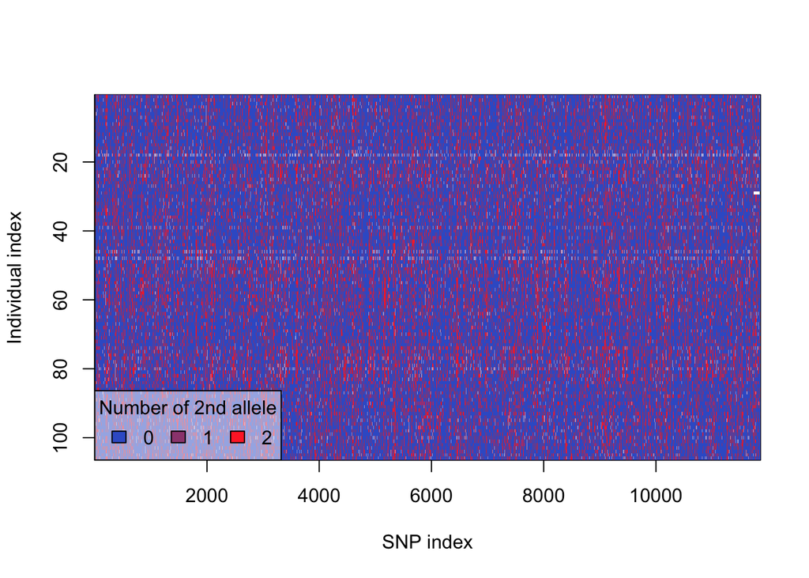

```r
x.dist <- dist(x)
glPlot(x)
```

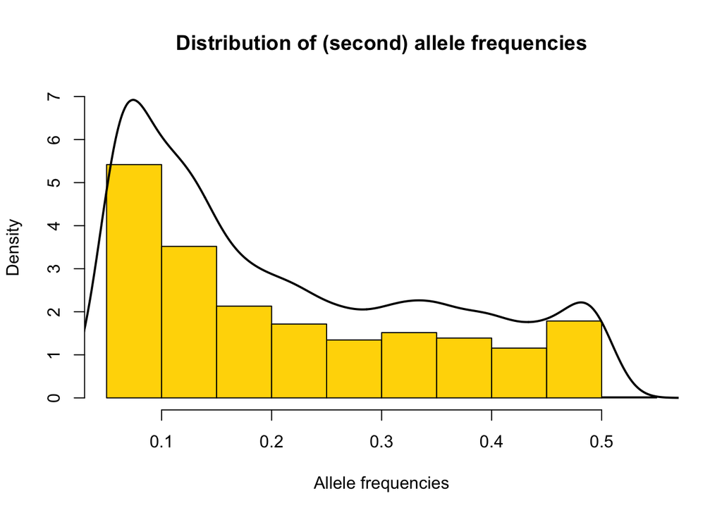

```r
myFreq <- glMean(x)
hist(myFreq, proba=TRUE, col="gold", xlab="Allele frequencies",
main="Distribution of (second) allele frequencies", ylim=c(0,7))
temp <- density(myFreq)
lines(temp$x, temp$y*1.5,lwd=2)
```

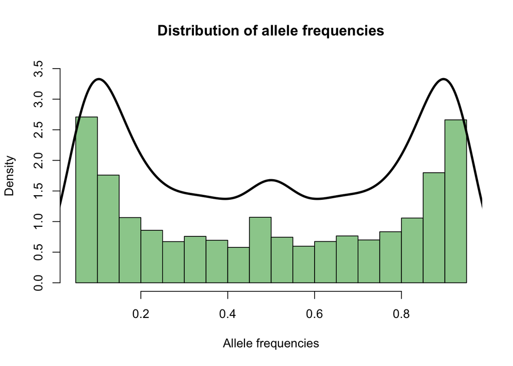

```r
myFreq <- glMean(x)
myFreq <- c(myFreq, 1-myFreq)
hist(myFreq, proba=TRUE, col="darkseagreen3", xlab="Allele frequencies",
main="Distribution of allele frequencies", nclass=20, ylim = c(0,3.5))
temp <- density(myFreq, bw=.05)
lines(temp$x, temp$y*2,lwd=3)
```

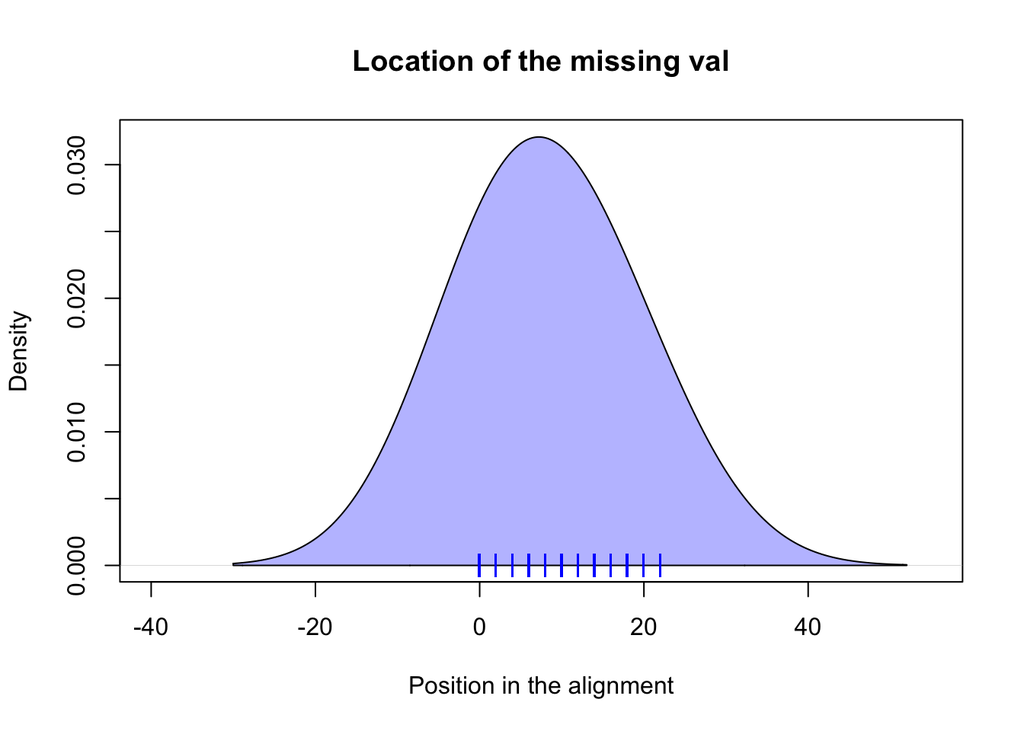

```r
temp <- density(glNA(x), bw=10)
plot(temp, type="n", xlab="Position in the alignment", main="Location of the missing val", xlim=c(-40,55))
polygon(c(temp$x,rev(temp$x)), c(temp$y, rep(0,length(temp$x))), col=transp("blue",.3))
points(glNA(x), rep(0, nLoc(x)), pch="|", col="blue")
```

[figure not shown]

```r
# An empty plot.
freq_peak_plot(pos=1:40)
```

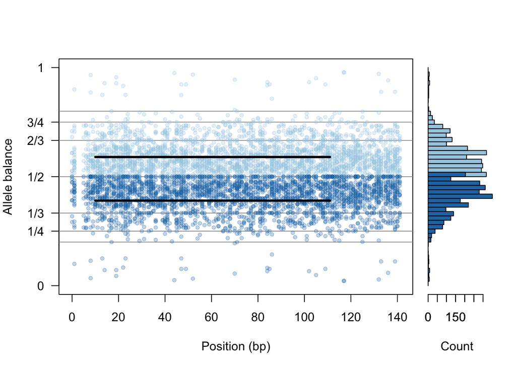

```r
gt <- extract.gt(vcf)
hets <- is_het(gt)
# Censor non-heterozygous positions.
is.na(vcf@gt[,-1][!hets]) <- TRUE
# Extract allele depths.
ad <- extract.gt(vcf, element = "AD")
ad1 <- masplit(ad, record = 1)
ad2 <- masplit(ad, record = 2)
freq1 <- ad1/(ad1+ad2)
freq2 <- ad2/(ad1+ad2)
myPeaks1 <- freq_peak(freq1, getPOS(vcf))
is.na(myPeaks1$peaks[myPeaks1$counts < 20]) <- TRUE
myPeaks2 <- freq_peak(freq2, getPOS(vcf), lhs = FALSE)
is.na(myPeaks2$peaks[myPeaks2$counts < 20]) <- TRUE
freq_peak_plot(pos = getPOS(vcf), ab1 = freq1, ab2 = freq2, fp1 = myPeaks1, fp2=myPeaks2)
```

```r
#ChromR object is not working
#chrom <- create.chromR(name="Supercontig", vcf=vcf, verbose=FALSE)
```

```r
#chrom
```

```r
#plot(chrom)
```

# Pre Processing

```r
#txt file won't load?
#I've tried a few different delim options
#And increasing the sys.setenv size
if (!requireNamespace("readr", quietly = TRUE)) {
  install.packages("readr", verbose = FALSE)
}

library(readr)
```

```r
#I got the txt file to load!
#but I'm not super sure what to do with it now?
#I assume I can do a join with something, but I have no idea what
Sys.setenv("VROOM_CONNECTION_SIZE" = 131072 * 4)
SNP <- read_delim("./Data/SNP.txt", delim = " ")
```

```
## ──────────────────────────────────────────────────────── Delimiter: " " dbl
## (11862): 0...1, 0...2, 1...3, 0...4, 0...5, 0...6, 0...7, 1...8, 1...9, ...
```

```r
data <- vcfR2tidy(vcf)
```

```
## Extracting gt element GT
```

```
## Extracting gt element DP
```

```
## Extracting gt element AD
```

```
## Extracting gt element GL
```

```r
#Summary of the all the samples
data$gt
```

```
## # A tibble: 1,257,372 × 8
##    ChromKey   POS Indiv gt_GT gt_DP gt_AD gt_GL     gt_GT_alleles
##       <int> <int> <chr> <chr> <int> <int> <chr>     <chr>
##  1     3155   111 FD02  <NA>     NA    NA <NA>      <NA>
##  2     3816    65 FD02  <NA>     NA    NA <NA>      <NA>
##  3     3816    98 FD02  1/0      36    22 .,49.91,. C/T
##  4     3945    79 FD02  <NA>     NA    NA <NA>      <NA>
##  5     4617    23 FD02  <NA>     NA    NA <NA>      <NA>
##  6     5501     0 FD02  <NA>     NA    NA <NA>      <NA>
##  7     6088    87 FD02  <NA>     NA    NA <NA>      <NA>
##  8     7452    44 FD02  1/0      46    31 .,63.77,. A/G
##  9     2396    25 FD02  0/1      14     6 .,19.41,. C/T
## 10     3129    33 FD02  1/0      26    12 .,36.04,. C/T
## # ℹ 1,257,362 more rows
```

```r
#metadata
data$meta
```

```
## # A tibble: 6 × 5
##   Tag    ID    Number Type    Description
##   <chr>  <chr> <chr>  <chr>   <chr>
## 1 INFO   NS    1      Integer Number of Samples With Data
## 2 INFO   AF    .      Float   Allele Frequency
## 3 FORMAT gt_GT 1      String  Genotype
## 4 FORMAT gt_DP 1      Integer Read Depth
## 5 FORMAT gt_AD 1      Integer Allele Depth
## 6 FORMAT gt_GL .      Float   Genotype Likelihood
```

```r
#summary of SNPs
data$fix
```

```
## # A tibble: 11,862 × 10
##    ChromKey CHROM   POS ID     REF   ALT    QUAL FILTER    NS AF
##       <int> <chr> <int> <chr>  <chr> <chr> <dbl> <chr>  <int> <chr>
##  1     3155 15      111 1_15   T     G        NA PASS      NA <NA>
##  2     3816 23       65 2_23   T     C        NA PASS      NA <NA>
##  3     3816 23       98 3_23   T     C        NA PASS      NA <NA>
##  4     3945 25       79 4_25   T     C        NA PASS      NA <NA>
##  5     4617 35       23 5_35   T     C        NA PASS      NA <NA>
##  6     5501 49        0 6_49   A     T        NA PASS      NA <NA>
##  7     6088 57       87 7_57   G     A        NA PASS      NA <NA>
##  8     7452 75       44 8_75   G     A        NA PASS      NA <NA>
##  9     2396 135      25 9_135  C     T        NA PASS      NA <NA>
## 10     3129 147      33 10_147 T     C        NA PASS      NA <NA>
## # ℹ 11,852 more rows
```